# ANALISE DO DATASET WINE QUALITY

RM334304 - EDUARDO SIQUEIRA DE LIMA

### **“Conceitos Estatísticos para IA”**

#### *Prof. Adelaide Alves de Oliveira*

Inicicalmente vamos instalar os pacotes, caso seja necessário, que serão usados no decorrer da análise

```r
#ignorando alertas para não poluir a exibição do markdwon
options(warn =-1)

#lista de pacotes que iremos utilizar no projeto
Pacotes_Necessarios <- c("ggplot2","readr","dplyr", "corrgram","corrplot", "plotly","skimr","gridExtra","GGally")

#com base nos pacotes instalados crio uma variavel somente com os pacotes que não temos ainda para realizar a instalação
#dos pacotes que de fato não possuimos
PacotesNovos <- Pacotes_Necessarios[!(Pacotes_Necessarios %in% installed.packages()[,"Package"])]
if(length(PacotesNovos)){ install.packages(PacotesNovos)} else {print("Todos os Pacotes Estão Instalados")}
```

```
[1] "Todos os Pacotes Estão Instalados"
```

Carregando todas as as Bibliotecas mencionadas no passo anterior

```r
lapply(Pacotes_Necessarios, require, character.only = TRUE)
```

```
[[1]]
[1] TRUE

[[2]]
[1] TRUE

[[3]]
[1] TRUE

[[4]]
[1] TRUE

[[5]]
[1] TRUE

[[6]]
[1] TRUE

[[7]]
[1] TRUE

[[8]]
[1] TRUE

[[9]]
[1] TRUE
```

Importando os Datasets de Wines Quality.

Os dados foram obtidos do site: https://archive.ics.uci.edu/ml/datasets/wine+quality, 2 arquivos foram baixados:

1. winequality-red.csv *(dados dos vinhos tintos)*
2. winequality-white.csv *(dados dos vinhos brancos)*

Analisando o arquivo antes de importar notamos que os nomes das colunas não são os mais amigaveis para fazer uma análise uma vez que alguns deles estão separados por espaço neste caso antes de subir iremos normaliza-los, para tal criaremos um array de nomes para passar como parâmetro no momento da carga dos dados

#### Lista DE - PARA das colunas

| Nome no Arquivo | Nome Traduzido |
| --- | --- |
| fixed acidity | acidez_fixa |
| volatile acidity | acidez_volatil |
| citric acid | acido_citrico |
| residual sugar | acucar_residual |
| chlorides | cloretos |
| free sulfur dioxide | fsd |
| total sulfur dioxide | tsd |
| density | densidade |
| pH | PH |
| sulphates | sulfatos |
| alcohol | grau_alcolico |
| quality | qualidade |

```r
#Criando uma variável nome_colunas que receberá os nomes das colunas que normalizaremos a fim de facilitar o resto da análise
nome_colunas <- c("acidez_fixa","acidez_volatil","acido_citrico","acucar_residual","cloretos", "fsd", "tsd","densidade","PH", "sulfatos","grau_alcolico","qualidade")

#uso da biblioteca readr é para obter uma performance de carga melhor que a lib padrão do R
vinho_branco <- read_delim("./DataSets/winequality-white.csv" ,delim = ";", col_names = nome_colunas, skip = 1)
```

```r
vinho_tinto  <- read_delim("./DataSets/winequality-red.csv"   ,delim = ";", col_names = nome_colunas, skip = 1)
```

```r
#Adicionando coluna tipo de vinho
vinho_branco$tipo <- "Branco"
vinho_tinto$tipo <- "Tinto"

#juntando os 2 datasets
vinhos <- rbind.data.frame(vinho_branco,vinho_tinto)

#converte tipo paara fator
vinhos$tipo <- factor(vinhos$tipo, ordered = T)

#Criando uma coluna de Ranking para dizer o quão bom é o vinho
vinhos$rating <- factor(ifelse(vinhos$qualidade <= 5, 'Ruim', ifelse(vinhos$qualidade <= 7, 'Bom', 'Excelente')))
```

Exibindo os dados das dimensões, sumário, estrutura e as primeiras linhas do DataFrame Vinhos

```r
attach(vinhos)
```

```r
#demonstrando as quantidades de dimensoes de ambos datasets

dim(vinhos)
```

```
[1] 6497   14
```

```r
skim(vinhos)
```

```
Skim summary statistics
 n obs: 6497
 n variables: 14

-- Variable type:factor --------------------------------------------------------
 variable missing complete    n n_unique                            top_counts ordered
   rating       0     6497 6497        3 Bom: 3915, Rui: 2384, Exc: 198, NA: 0   FALSE
     tipo       0     6497 6497        2           Bra: 4898, Tin: 1599, NA: 0    TRUE

-- Variable type:numeric -------------------------------------------------------
        variable missing complete    n    mean     sd    p0    p25     p50     p75   p100     hist
     acidez_fixa       0     6497 6497   7.22   1.3   3.8    6.4     7       7.7    15.9  ▁▇▇▂▁▁▁▁
  acidez_volatil       0     6497 6497   0.34   0.16  0.08   0.23    0.29    0.4     1.58 ▇▇▂▁▁▁▁▁
   acido_citrico       0     6497 6497   0.32   0.15  0      0.25    0.31    0.39    1.66 ▂▇▂▁▁▁▁▁
 acucar_residual       0     6497 6497   5.44   4.76  0.6    1.8     3       8.1    65.8  ▇▂▁▁▁▁▁▁
        cloretos       0     6497 6497   0.056  0.035 0.009  0.038   0.047   0.065   0.61 ▇▁▁▁▁▁▁▁
       densidade       0     6497 6497   0.99   0.003 0.99   0.99    0.99    1       1.04 ▅▇▁▁▁▁▁▁
             fsd       0     6497 6497  30.53  17.75  1     17      29      41     289    ▇▃▁▁▁▁▁▁
   grau_alcolico       0     6497 6497  10.49   1.19  8      9.5    10.3    11.3    14.9  ▁▇▆▆▃▂▁▁
              PH       0     6497 6497   3.22   0.16  2.72   3.11    3.21    3.32    4.01 ▁▃▇▇▃▁▁▁
       qualidade       0     6497 6497   5.82   0.87  3      5       6       6       9    ▁▁▆▇▁▃▁▁
        sulfatos       0     6497 6497   0.53   0.15  0.22   0.43    0.51    0.6     2    ▅▇▂▁▁▁▁▁
             tsd       0     6497 6497 115.74  56.52  6     77     118     156     440    ▅▆▇▃▁▁▁▁
```

```r
str(vinhos)
```

```
Classes ‘spec_tbl_df’, ‘tbl_df’, ‘tbl’ and 'data.frame':    6497 obs. of  14 variables:
 $ acidez_fixa    : num  7 6.3 8.1 7.2 7.2 8.1 6.2 7 6.3 8.1 ...
 $ acidez_volatil : num  0.27 0.3 0.28 0.23 0.23 0.28 0.32 0.27 0.3 0.22 ...
 $ acido_citrico  : num  0.36 0.34 0.4 0.32 0.32 0.4 0.16 0.36 0.34 0.43 ...
 $ acucar_residual: num  20.7 1.6 6.9 8.5 8.5 6.9 7 20.7 1.6 1.5 ...
 $ cloretos       : num  0.045 0.049 0.05 0.058 0.058 0.05 0.045 0.045 0.049 0.044 ...
 $ fsd            : num  45 14 30 47 47 30 30 45 14 28 ...
 $ tsd            : num  170 132 97 186 186 97 136 170 132 129 ...
 $ densidade      : num  1.001 0.994 0.995 0.996 0.996 ...
 $ PH             : num  3 3.3 3.26 3.19 3.19 3.26 3.18 3 3.3 3.22 ...
 $ sulfatos       : num  0.45 0.49 0.44 0.4 0.4 0.44 0.47 0.45 0.49 0.45 ...
 $ grau_alcolico  : num  8.8 9.5 10.1 9.9 9.9 10.1 9.6 8.8 9.5 11 ...
 $ qualidade      : num  6 6 6 6 6 6 6 6 6 6 ...
 $ tipo           : Ord.factor w/ 2 levels "Branco"<"Tinto": 1 1 1 1 1 1 1 1 1 1 ...
 $ rating         : Factor w/ 3 levels "Bom","Excelente",..: 1 1 1 1 1 1 1 1 1 1 ...
 - attr(*, "spec")=
  .. cols(
  ..   acidez_fixa = col_double(),
  ..   acidez_volatil = col_double(),
  ..   acido_citrico = col_double(),
  ..   acucar_residual = col_double(),
  ..   cloretos = col_double(),
  ..   fsd = col_double(),
  ..   tsd = col_double(),
  ..   densidade = col_double(),
  ..   PH = col_double(),
  ..   sulfatos = col_double(),
  ..   grau_alcolico = col_double(),
  ..   qualidade = col_double()
  .. )
```

```r
head (vinhos,3)
```

| acidez_fixa | acidez_volatil | acido_citrico | acucar_residual | cloretos | fsd | tsd | densidade | PH | sulfatos | grau_alcolico | qualidade | tipo | rating |
| --- | --- | --- | --- | --- | --- | --- | --- | --- | --- | --- | --- | --- | --- |
| 7.0 | 0.27 | 0.36 | 20.7 | 0.045 | 45 | 170 | 1.0010 | 3.00 | 0.45 | 8.8 | 6 | Branco | Bom |
| 6.3 | 0.30 | 0.34 | 1.6 | 0.049 | 14 | 132 | 0.9940 | 3.30 | 0.49 | 9.5 | 6 | Branco | Bom |
| 8.1 | 0.28 | 0.40 | 6.9 | 0.050 | 30 | 97 | 0.9951 | 3.26 | 0.44 | 10.1 | 6 | Branco | Bom |

```r
NA
```

Distribuição da Qualidade do Vinho por tipo de vinho e classificação

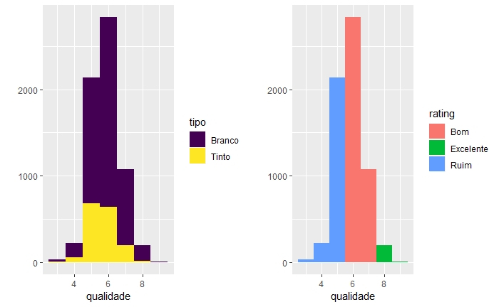

```r
grafico_1 <- qplot(qualidade, data = vinhos, fill = tipo, binwidth = 1)
grafico_2 <- qplot(qualidade, data = vinhos, fill = rating, binwidth = 1)

grid.arrange(grafico_1, grafico_2, ncol=2)
```

O comando aplicado para todos atributos abaixo exibição dos box-plot abaixo foi:

> *boxplot(Column_Name, col=“slategray2”, pch=19)*  
> *mtext(“Titulo” , cex=0.8, side=1, line=2)*

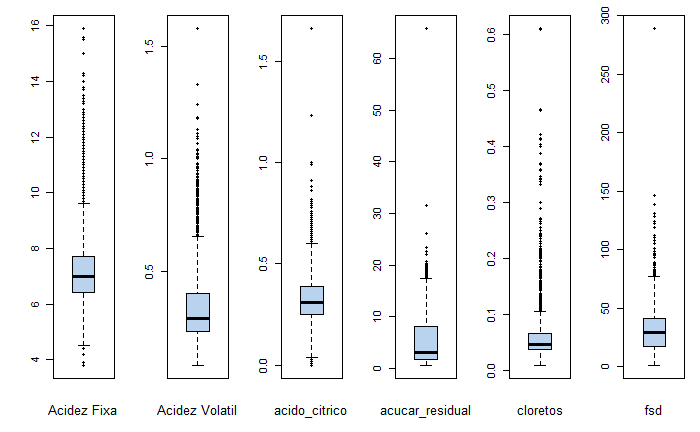

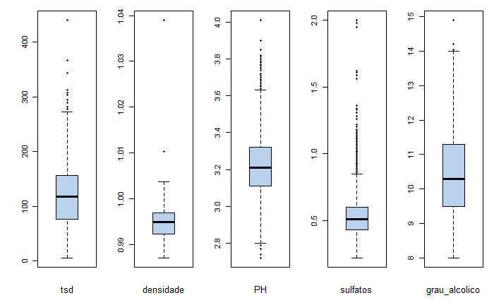

Nota se que todas as variáveis possuem outliers e para uma melhor acurácia no modelo iremos removê-las da análise inicial

```r
#criando uma funcao para remover os outliers das colunas
remove_outliers <- function(x, na.rm = TRUE, ...) {
  qnt <- quantile(x, probs=c(.25, .75), na.rm = na.rm, ...)
  H <- 1.5 * IQR(x, na.rm = na.rm)
  y <- x
  y[x < (qnt[1] - H)] <- NA
  y[x > (qnt[2] + H)] <- NA
  y
}
```